## Can Institutions Buffer for Emerging Market Exchange Rates Movement under Geopolitical Shocks?

The Hong Kong University of Science and Technology

# Can Institutions Buffer for Emerging Market Exchange Rates Movement under Geopolitical Shocks?

Presenters: **Ivan, Leon, Wilson**  
16/11/2026

## Research logic flow

Model 1 · Baseline

Institutions × GPR  
→ Exchange rate

Model 2 · Export channel

Institutions → Exports  
→ Exchange rate

Model 3 · Inflation channel

Inflation → Exports  
→ Exchange rate

Model 1 · Expectation

Stronger institutions are associated with stronger currencies.

Model 2 · Expectation

A two-stage arrangement that shows institution affects exchange rates through exports.

Model 3 · Expectation

Institutional quality and its interaction with GPR may shape the inflation channel, explaining the variation in exports and exchange rates.

**Interested Question:** Through what channels does institution matter? What is institutional quality in essence?

## Breaking Down Institutions

Voice and Accountability

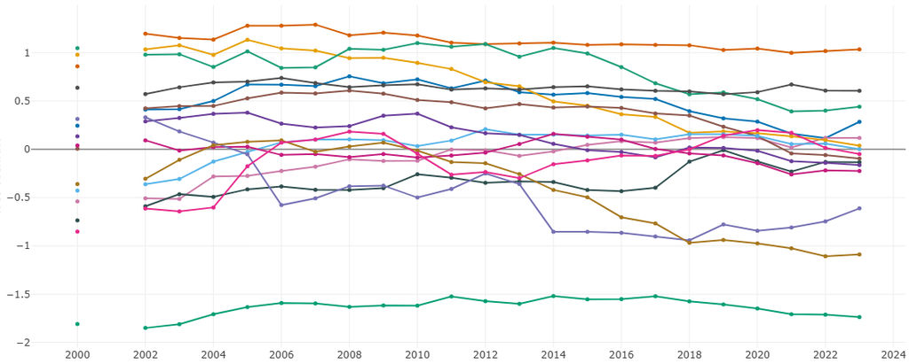

Political Stability

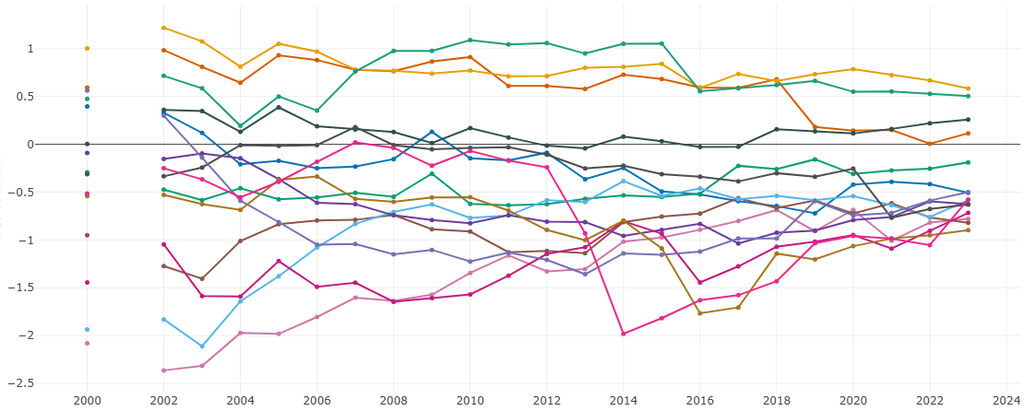

Government Effectiveness

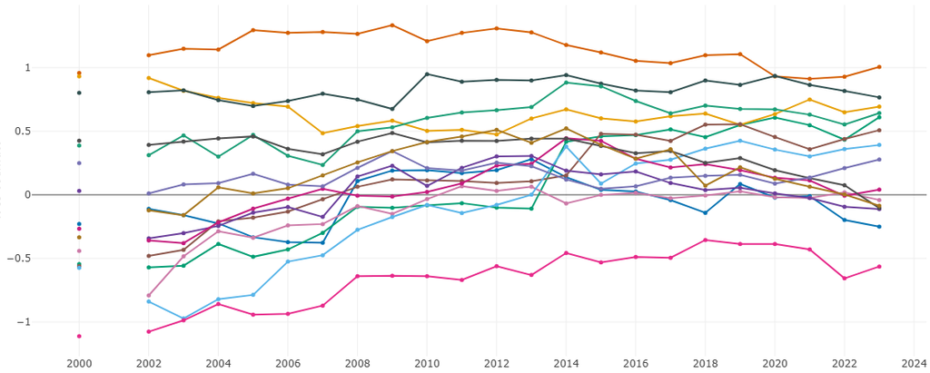

Regulatory Quality

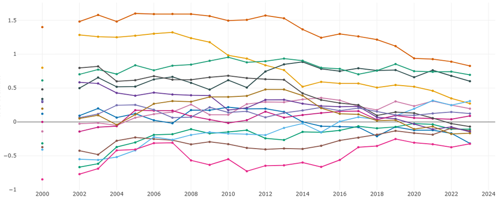

Rule of Law

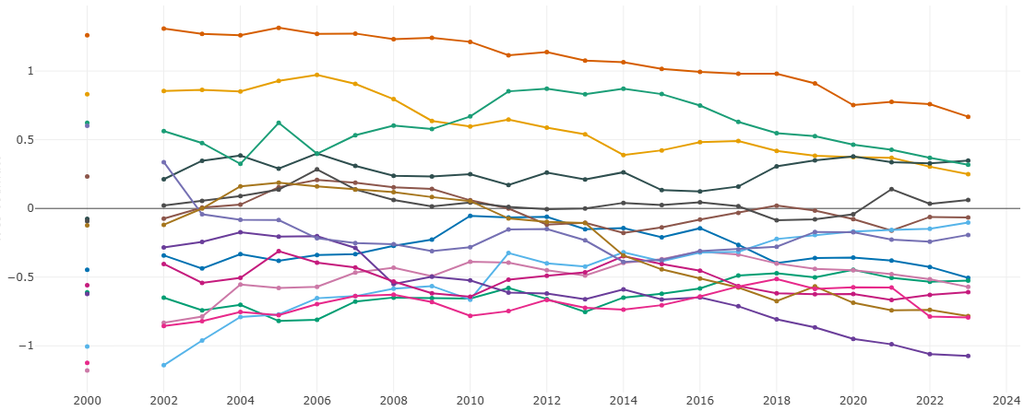

Control of Corruption

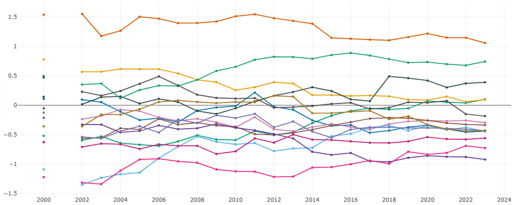

| WGI Aspect | Reflects: |
| --- | --- |
| 1. Voice & Accountability | Democratic participation and media freedom |
| 2. Political Stability | Absence of politically motivated violence |
| 3. Government Effectiveness | Public service and infrastructure quality |
| 4. Regulatory Quality | Market-friendly policies and economic freedom |
| 5. Rule of Law | Property rights and contract enforcement |
| 6. Control of Corruption | Public transparency and anti-bribery enforcement |

Caveats

In general, there is no common trend in institutional movement.

## Two channels

What we investigate

Export channel

GPR and WGI may move the real exchange rate through exports: institutions and risk first affect export volumes, then the currency.

Capital-flow channel

GPR and WGI may also move the currency through capital-flow volatility: portfolio inflows become more or less volatile when geopolitical risk rises.

## Model 1 | Design

Direct exchange-rate relationship

$$\log REER_{it} = \alpha_i + \beta_1 GPR_{it} + \beta_2 WGI_{i,t-1}
+ \beta_3 (WGI_{i,t-1}\times GPR_{it})
+ \boldsymbol{\gamma}^{\mathsf T}\mathbf{X}_{i,t-1} + \varepsilon_{it}.$$

**Variables:** REER is the real effective exchange rate; WGI is one of six governance dimensions; GPR is standardized within country; X can be referred to variables below.  
**Estimation:** Country fixed effects; country-clustered standard errors.

| Category | Variable | Measurement | Role |
| --- | --- | --- | --- |
| Country | Institutional quality | WGI score | Main variable of interest; six governance dimensions |
|  | Geopolitical risk | GPR score | Variable of interest |
|  | Policy rate | Central bank policy interest rate | Controls for monetary tightening and easing |
|  | Inflation | Year-on-year change in CPI | Controls for domestic purchasing-power erosion |
| Global | Economic policy uncertainty | Log of the global EPU index | Controls for global economic policy uncertainty |
|  | Financial uncertainty | Log of the CBOE VIX | Controls for global financial risk |
|  | Oil prices | Log of WTI crude oil price | Controls for global energy price shocks |
|  | Public debt / GDP | IMF WEO government debt-to-GDP ratio | Controls for fiscal and sovereign-risk conditions |
|  | Financial development | IMF Financial Development Index | Controls for financial-market development and liquidity |

## Model 1 | Results: exchange rate

| Variable | Voice and accountability | Political stability | Government effectiveness | Regulatory quality | Rule of law | Control of corruption |
| --- | --- | --- | --- | --- | --- | --- |
| GPR | 0.0006 (0.0031) | 0.0023 (0.0034) | 0.0009 (0.0030) | 0.0001 (0.0032) | 0.0005 (0.0033) | -0.0003 (0.0028) |
| WGI | 0.1366 (0.0863) | **0.0658*** (0.0375) | **0.1002*** (0.0564) | **0.1389**** (0.0547) | **0.1673*** (0.0848) | **0.1204*** (0.0690) |
| WGI × GPR | **-0.0091*** (0.0053) | -0.0002 (0.0033) | -0.0014 (0.0044) | -0.0020 (0.0049) | -0.0036 (0.0041) | -0.0009 (0.0030) |
| Policy rate | 0.0021 (0.0025) | **0.0036*** (0.0020) | **0.0052***** (0.0018) | **0.0038**** (0.0018) | 0.0033 (0.0020) | **0.0040**** (0.0019) |
| Inflation | **-0.0098***** (0.0032) | **-0.0112***** (0.0022) | **-0.0121***** (0.0020) | **-0.0117***** (0.0021) | **-0.0104***** (0.0027) | **-0.0116***** (0.0023) |
| Log oil price | **0.0484**** (0.0181) | **0.0611***** (0.0168) | **0.0650***** (0.0163) | **0.0655***** (0.0160) | **0.0634***** (0.0161) | **0.0682***** (0.0150) |
| Log VIX | 0.0147 (0.0095) | 0.0132 (0.0096) | **0.0231**** (0.0108) | **0.0198*** (0.0100) | **0.0193*** (0.0103) | 0.0156 (0.0105) |
| Log global EPU | -0.0178 (0.0202) | -0.0195 (0.0210) | -0.0355 (0.0238) | -0.0218 (0.0222) | -0.0179 (0.0209) | -0.0246 (0.0225) |
| Financial development | 0.1900 (0.2753) | 0.2663 (0.2991) | 0.1745 (0.2296) | 0.1512 (0.2795) | 0.2100 (0.2687) | 0.1962 (0.2595) |
| Debt/GDP | **-0.0014*** (0.0008) | **-0.0014*** (0.0007) | -0.0011 (0.0008) | -0.0008 (0.0010) | -0.0013 (0.0008) | -0.0010 (0.0010) |
| Observations | 6628 27 countries 2000-02 to 2022-01 | 6628 27 countries 2000-02 to 2022-01 | 6628 27 countries 2000-02 to 2022-01 | 6628 27 countries 2000-02 to 2022-01 | 6628 27 countries 2000-02 to 2022-01 | 6628 27 countries 2000-02 to 2022-01 |

Country-clustered SE in parentheses; confidence intervals omitted. Bold in highlighted rows: p < .10. *** p < .01, ** p < .05, * p < .10.

## Ideas for Interpretation

01

Institutional dimensions and controls

Voice & Accountability, Government Effectiveness, Rule of Law, and Control of Corruption capture institutional qualities distinct from the macro controls.

02

GPR after adding WGI

- The GPR coefficient is statistically insignificant in all six WGI specifications.
- This does not by itself establish that adding WGI caused the loss of significance.
- The correlations below do not suggest strong pairwise multicollinearity between GPR and the WGI measures.

| Correlation Matrix | Voice and Accountability | Political Stability | Government Effectiveness | Regulatory Quality | Rule of Law | Control of Corruption |
| --- | --- | --- | --- | --- | --- | --- |
| Country GPR | -0.035 | -0.159 | -0.135 | -0.091 | -0.062 | -0.079 |

## Ideas for Interpretation

03

Institutions and the exchange-rate level

- WGI coefficients are positive in all six specifications and significant in five at 10% (one at 5%).
- Interaction terms are insignificant at 5%; the Voice and Accountability interaction is significant at 10%.
- Stronger institutions may support confidence and a stronger REER.

04

Differences in variation over time

If institutional quality and GPR vary less than exchange rates over long horizons, their interaction may be less able to explain exchange-rate fluctuations significantly.

## Model 2 | Design

Original six-country specification

$$x_{it} = \alpha_i + \pi_1 GPR_{it} + \pi_2 WGI_{i,t-1}
+ \pi_3 (WGI_{i,t-1}\times GPR_{it})
+ \pi_4\log VIX_{t-1} + \pi_5\Delta IP_{i,t-1} + u_{it}.$$

$$\log REER_{it} = \mu_i + \theta\,\widetilde{\widehat{x}}_{it}
+ \boldsymbol{\delta}^{\mathsf T}\mathbf{X}_{i,t-1} + \eta_{it}.$$

- $x$: Hodrick–Prescott log trend of nominal exports; $\Delta IP$: year-over-year industrial-production growth.
- $\widetilde{\widehat{x}}$: first-stage fitted export trend demeaned within country; $\mathbf X$ is the exchange-rate control set from Model 1.
- GPR, WGI, their interaction and IP growth are excluded from the second-stage equation. The staged interpretation depends on exclusion and instrument-strength assumptions.

## Model 2 | Results: first stage

| Variable | Voice and accountability | Political stability | Government effectiveness | Regulatory quality | Rule of law | Control of corruption |
| --- | --- | --- | --- | --- | --- | --- |
| GPR | -0.0238 (0.0275) | 0.0203 (0.0201) | 0.0499 (0.0413) | 0.0060 (0.0265) | -0.0048 (0.0183) | 0.0089 (0.0300) |
| WGI | **-1.7545***** (0.3423) | **-0.9913*** (0.4003) | 0.5004 (0.7104) | **-1.3564*** (0.5425) | **-2.0261***** (0.3624) | **-1.7041**** (0.6413) |
| WGI × GPR | 0.0113 (0.0387) | 0.0579 (0.0300) | -0.0270 (0.0920) | 0.0042 (0.0762) | 0.0080 (0.0273) | 0.0037 (0.0270) |
| Log VIX | 0.0631 (0.0609) | -0.0145 (0.0872) | **-0.0917**** (0.0298) | -0.0740 (0.0582) | -0.0239 (0.0766) | 0.0140 (0.0606) |
| Industrial-production growth | -0.0007 (0.0020) | 0.0022 (0.0028) | -0.0000 (0.0017) | -0.0001 (0.0025) | 0.0004 (0.0023) | 0.0015 (0.0018) |
| Observations | 1149 6 countries 2006-01 to 2022-01 | 1149 6 countries 2006-01 to 2022-01 | 1149 6 countries 2006-01 to 2022-01 | 1149 6 countries 2006-01 to 2022-01 | 1149 6 countries 2006-01 to 2022-01 | 1149 6 countries 2006-01 to 2022-01 |
| Partial F on the excluded instruments | **12.22** **p=0.0086** F(4, 5) | **34.68** **p=0.0008** F(4, 5) | **3.89** **p=0.0842** F(4, 5) | **4.91** **p=0.0554** F(4, 5) | **23.34** **p=0.0020** F(4, 5) | **58.10** **p=0.0002** F(4, 5) |

Coefficients with country-clustered standard errors in parentheses; confidence intervals omitted. Bold: p < .10. *** p < .01, ** p < .05, * p < .10.

## Model 2 | Results: second stage

| Variable | Voice and accountability | Political stability | Government effectiveness | Regulatory quality | Rule of law | Control of corruption |
| --- | --- | --- | --- | --- | --- | --- |
| Fitted nominal-export trend | **-0.1515***** (0.0312) | -0.1124 (0.0845) | 0.1143 (0.1927) | -0.2603 (0.1510) | **-0.1551***** (0.0295) | **-0.1691**** (0.0539) |
| Policy rate | **-0.0037**** (0.0010) | **-0.0039*** (0.0018) | -0.0008 (0.0034) | **-0.0046**** (0.0015) | **-0.0034**** (0.0010) | -0.0030 (0.0019) |
| Inflation | **-0.0138**** (0.0042) | **-0.0168***** (0.0035) | -0.0191 (0.0106) | -0.0118 (0.0076) | **-0.0138**** (0.0041) | **-0.0135**** (0.0050) |
| Log oil price | 0.0466 (0.0246) | **0.0863**** (0.0287) | 0.0906 (0.0567) | 0.0567 (0.0430) | **0.0656*** (0.0270) | 0.0580 (0.0330) |
| Log VIX | -0.0178 (0.0275) | 0.0150 (0.0402) | 0.0482 (0.0780) | -0.0041 (0.0591) | -0.0159 (0.0319) | 0.0027 (0.0408) |
| Log global EPU | -0.0160 (0.0408) | -0.0919 (0.0635) | -0.1202 (0.0914) | -0.0556 (0.1132) | -0.0232 (0.0515) | -0.0844 (0.0788) |
| Financial development | 0.0535 (0.4458) | 0.2080 (0.3596) | 0.1048 (0.9701) | -0.9933 (1.0814) | 0.1080 (0.3728) | -0.1513 (0.3857) |
| Debt/GDP | -0.0018 (0.0013) | -0.0007 (0.0023) | 0.0003 (0.0044) | 0.0019 (0.0051) | -0.0010 (0.0016) | 0.0014 (0.0028) |
| Observations | 1149 6 countries 2006-01 to 2022-01 | 1149 6 countries 2006-01 to 2022-01 | 1149 6 countries 2006-01 to 2022-01 | 1149 6 countries 2006-01 to 2022-01 | 1149 6 countries 2006-01 to 2022-01 | 1149 6 countries 2006-01 to 2022-01 |

Coefficients with country-clustered standard errors in parentheses; confidence intervals omitted. Bold: p < .10. *** p < .01, ** p < .05, * p < .10.

## Model 2 | Findings and interpretation

Significant results

- WGI is negative at 5% for VA, RL and CC, evaluated at average country GPR.
- Fitted exports are negatively associated with log REER for VA, RL and CC.
- No WGI × GPR interaction is significant at 5%.

Conclusion

The negative institutional association with exports is contrary to our prediction; it does not establish that weaker institutions cause exports to rise.

Possible mechanism

Exports can be further broken down into real exports, which represent quantity, and inflation, which represents price.

Only six country clusters; the reported partial F is low for GE and RQ. Exclusion restrictions and weak instruments require further scrutiny.

## Model 3 | Design

Inflation and real exports → nominal exports → exchange rate

$$\begin{aligned}
\pi_{it} &= \alpha_i^{\pi} + a_1 M_{i,t-1} + a_2 r_{i,t-1}
+ a_3GPR_{it} + a_4WGI_{i,t-1} + a_5(WGI_{i,t-1}GPR_{it}) + u_{it}^{\pi},\\
x^R_{it} &= \alpha_i^R + b_1\Delta IP_{i,t-1} + b_2\log VIX_{t-1}
+ b_3GPR_{it} + b_4WGI_{i,t-1} + b_5(WGI_{i,t-1}GPR_{it}) + u_{it}^{R},\\
x^N_{it} &= \alpha_i^N + c_1\widetilde{\widehat{\pi}}_{it}
+ c_2\widetilde{\widehat{x^R}}_{it} + c_3\log VIX_{t-1}
+ c_4\Delta IP_{i,t-1} + u_{it}^{N},\\
\log REER_{it} &= \mu_i + d_1\widetilde{\widehat{x^N}}_{it}
+ \boldsymbol{\delta}^{\mathsf T}\mathbf X_{i,t-1} + \eta_{it}.
\end{aligned}$$

$M$: import share of GDP; $r$: policy rate; $\pi$: inflation; $x^R$, $x^N$: real- and nominal-export log trends. Tildes denote within-country demeaning of fitted series. $\mathbf X$ is the Model 1 exchange-rate control set, including lagged observed inflation. The stages are fitted sequentially.

## Model 3 | Results: inflation

| Variable | Voice and accountability | Political stability | Government effectiveness | Regulatory quality | Rule of law | Control of corruption |
| --- | --- | --- | --- | --- | --- | --- |
| Import share of GDP | 11.6645 (22.6958) | 16.3191 (17.3934) | 24.4967 (19.3169) | 22.8710 (23.6930) | 10.7729 (23.6858) | 16.2027 (17.2694) |
| Policy rate | **0.5387***** (0.0566) | **0.5448***** (0.0398) | **0.4445***** (0.0708) | **0.5213***** (0.0460) | **0.5383***** (0.0416) | **0.5210***** (0.0448) |
| GPR | -0.0370 (0.1503) | -0.0624 (0.1191) | -0.0286 (0.0710) | -0.0089 (0.0899) | 0.0013 (0.1373) | 0.0072 (0.1010) |
| WGI | -2.3309 (2.5726) | **-3.2245**** (0.9129) | **-4.0752*** (1.5947) | -0.6627 (1.7661) | -2.7017 (3.4843) | -2.0236 (1.0752) |
| WGI × GPR | 0.2065 (0.1953) | 0.1300 (0.1714) | -0.0246 (0.2092) | -0.1877 (0.2239) | 0.2103 (0.1816) | 0.0986 (0.1862) |
| Observations | 956 5 countries 2006-01 to 2022-01 | 956 5 countries 2006-01 to 2022-01 | 956 5 countries 2006-01 to 2022-01 | 956 5 countries 2006-01 to 2022-01 | 956 5 countries 2006-01 to 2022-01 | 956 5 countries 2006-01 to 2022-01 |
| Partial F on the excluded instruments | **13.73** **p=0.0132** F(4, 4) | **19.96** **p=0.0066** F(4, 4) | **41.99** **p=0.0016** F(4, 4) | 1.95 p=0.2662 F(4, 4) | **429.13** **p=0.0000** F(4, 4) | **33.19** **p=0.0025** F(4, 4) |

Coefficients with country-clustered standard errors in parentheses; confidence intervals omitted. Bold: p < .10. *** p < .01, ** p < .05, * p < .10.

## Model 3 | Results: real exports

| Variable | Voice and accountability | Political stability | Government effectiveness | Regulatory quality | Rule of law | Control of corruption |
| --- | --- | --- | --- | --- | --- | --- |
| Industrial-production growth | -0.0005 (0.0011) | 0.0013 (0.0011) | -0.0000 (0.0008) | 0.0004 (0.0009) | 0.0008 (0.0006) | **0.0011*** (0.0005) |
| Log VIX | 0.0213 (0.0244) | -0.0163 (0.0437) | **-0.0608*** (0.0264) | -0.0311 (0.0361) | -0.0101 (0.0484) | 0.0055 (0.0351) |
| GPR | -0.0097 (0.0113) | 0.0131 (0.0102) | 0.0349 (0.0241) | 0.0057 (0.0142) | 0.0002 (0.0092) | 0.0082 (0.0154) |
| WGI | **-0.8313***** (0.1379) | **-0.5409**** (0.1576) | 0.0759 (0.3592) | **-0.7365*** (0.2731) | **-1.0090***** (0.1363) | **-1.0037**** (0.2835) |
| WGI × GPR | -0.0033 (0.0198) | 0.0334 (0.0188) | -0.0090 (0.0532) | -0.0076 (0.0353) | -0.0042 (0.0137) | -0.0013 (0.0128) |
| Observations | 956 5 countries 2006-01 to 2022-01 | 956 5 countries 2006-01 to 2022-01 | 956 5 countries 2006-01 to 2022-01 | 956 5 countries 2006-01 to 2022-01 | 956 5 countries 2006-01 to 2022-01 | 956 5 countries 2006-01 to 2022-01 |
| Partial F on the excluded instruments | **20.55** **p=0.0068** F(3, 4) | **4.63** **p=0.0863** F(3, 4) | **4.21** **p=0.0994** F(3, 4) | 3.45 p=0.1313 F(3, 4) | **82.91** **p=0.0005** F(3, 4) | **46.73** **p=0.0014** F(3, 4) |

Coefficients with country-clustered standard errors in parentheses; confidence intervals omitted. Bold: p < .10. *** p < .01, ** p < .05, * p < .10.

## Model 3 | Results: nominal exports

| Variable | Voice and accountability | Political stability | Government effectiveness | Regulatory quality | Rule of law | Control of corruption |
| --- | --- | --- | --- | --- | --- | --- |
| Fitted inflation | 0.0325 (0.0284) | 0.0525 (0.0336) | 0.0689 (0.0886) | 0.0528 (0.0400) | 0.0282 (0.0264) | 0.0171 (0.0147) |
| Fitted real-export trend | **2.0439***** (0.1527) | **1.7476**** (0.4480) | **2.7071*** (1.0282) | **1.9137***** (0.2677) | **2.0848***** (0.1334) | **1.9127***** (0.1878) |
| Log VIX | 0.0186 (0.0490) | 0.0065 (0.0857) | 0.0523 (0.0872) | 0.0041 (0.0707) | 0.0183 (0.0479) | 0.0081 (0.0470) |
| Industrial-production growth | 0.0012 (0.0010) | 0.0022 (0.0019) | 0.0018 (0.0025) | 0.0017 (0.0016) | 0.0012 (0.0010) | 0.0011 (0.0009) |
| Observations | 956 5 countries 2006-01 to 2022-01 | 956 5 countries 2006-01 to 2022-01 | 956 5 countries 2006-01 to 2022-01 | 956 5 countries 2006-01 to 2022-01 | 956 5 countries 2006-01 to 2022-01 | 956 5 countries 2006-01 to 2022-01 |
| Partial F on the excluded instruments | **68.37** **p=0.0007** F(3, 4) | **10.26** **p=0.0238** F(3, 4) | **5.69** **p=0.0631** F(3, 4) | **51.53** **p=0.0012** F(3, 4) | **155.26** **p=0.0001** F(3, 4) | **64.30** **p=0.0008** F(3, 4) |

Coefficients with country-clustered standard errors in parentheses; confidence intervals omitted. Bold: p < .10. *** p < .01, ** p < .05, * p < .10.

## Model 3 | Results: exchange rate

| Variable | Voice and accountability | Political stability | Government effectiveness | Regulatory quality | Rule of law | Control of corruption |
| --- | --- | --- | --- | --- | --- | --- |
| Fitted nominal-export trend | **-0.1572**** (0.0345) | -0.1011 (0.0909) | -0.2782 (0.2730) | -0.2615 (0.1772) | **-0.1782***** (0.0277) | **-0.1821*** (0.0775) |
| Policy rate | -0.0019 (0.0012) | -0.0019 (0.0018) | 0.0048 (0.0126) | 0.0007 (0.0070) | -0.0023 (0.0016) | -0.0029 (0.0028) |
| Inflation | **-0.0130*** (0.0049) | **-0.0161**** (0.0041) | -0.0175 (0.0128) | -0.0101 (0.0061) | **-0.0125*** (0.0045) | **-0.0116*** (0.0048) |
| Log oil price | **0.0686**** (0.0198) | **0.1123**** (0.0253) | 0.1070 (0.0516) | 0.0803 (0.0499) | **0.0869**** (0.0233) | **0.0813*** (0.0358) |
| Log VIX | -0.0017 (0.0220) | 0.0374 (0.0427) | 0.0189 (0.0833) | 0.0073 (0.0689) | -0.0151 (0.0282) | 0.0135 (0.0490) |
| Log global EPU | 0.0068 (0.0516) | -0.0843 (0.0784) | -0.0918 (0.1500) | -0.0265 (0.1414) | 0.0249 (0.0659) | -0.0593 (0.1019) |
| Financial development | 0.0304 (0.4677) | 0.1805 (0.3972) | 0.0781 (1.0855) | -1.0553 (1.2072) | 0.1588 (0.3699) | -0.2288 (0.4356) |
| Debt/GDP | -0.0022 (0.0013) | -0.0010 (0.0023) | -0.0006 (0.0062) | 0.0027 (0.0059) | -0.0006 (0.0015) | 0.0023 (0.0029) |
| Observations | 956 5 countries 2006-01 to 2022-01 | 956 5 countries 2006-01 to 2022-01 | 956 5 countries 2006-01 to 2022-01 | 956 5 countries 2006-01 to 2022-01 | 956 5 countries 2006-01 to 2022-01 | 956 5 countries 2006-01 to 2022-01 |

Coefficients with country-clustered standard errors in parentheses; confidence intervals omitted. Bold: p < .10. *** p < .01, ** p < .05, * p < .10.

## Model 3 | Findings and interpretation

Significant results

- Fitted real exports are positively associated with nominal exports in five of six columns at 5%.
- Fitted nominal exports are negatively associated with log REER for VA and RL at 5%.
- Fitted inflation is not significant at 10% in the nominal-export equation.

Conclusion

## Model 3 | Intuition and qualitative arguments

Intuition

External shocks and institutions may influence prices and production separately before affecting nominal exports and exchange rates.

Explanations

Import dependence and price pass-through can alter the result of the export channel.

## Capital-flow volatility | Design

Equation (2) with one WGI dimension

$$vol_{it} = \alpha_i + \beta_1 GPR_{it}^{z} + \beta_2 WGI_{i,t-1}
+ \beta_3 (WGI_{i,t-1}\times GPR_{it}^{z})
+ \boldsymbol{\gamma}^{\mathsf T}\mathbf{X}_{i,t-1} + \varepsilon_{it}.$$

Outcome

- $vol$: three-month standard deviation of gross portfolio inflows, billion dollars
- $GPR^{z}$: country article share, standardized within country
- $WGI$: rule of law, government effectiveness, or regulatory quality, lagged and centered

Controls and estimation

- $\mathbf X$: policy rate, log industrial production, inflation, log oil, log VIX, log global EPU, financial development, central-bank independence, debt/GDP
- Country fixed effects; country-clustered standard errors

Table 2’s GPR coefficient of 0.867 is a paper reference with no WGI term. Ukraine, Thailand, Indonesia, the Philippines and South Africa have no complete month.

## Capital-flow volatility | Rule of law

| Variable | Within | Cluster |
| --- | --- | --- |
| GPR | **-0.5852***** (0.1911) | -0.5852 (0.4597) |
| WGI | **-13.1173***** (1.5267) | -13.1173 (10.5582) |
| WGI × GPR | -0.3404 (0.2357) | **-0.3404**** (0.1542) |
| Policy rate | -0.0274 (0.1042) | -0.0274 (0.1257) |
| Real industrial production | **5.7441***** (1.4655) | 5.7441 (4.8178) |
| Inflation | -0.0791 (0.1097) | -0.0791 (0.0950) |
| Oil price | **1.8332***** (0.5239) | **1.8332*** (1.0695) |
| VIX | **3.9447***** (0.5999) | 3.9447 (2.7754) |
| Global EPU | **-1.6293**** (0.6721) | -1.6293 (1.8417) |
| Financial development | -0.6453 (5.6719) | -0.6453 (15.1680) |
| Central bank independence | -18.1654 (12.4743) | -18.1654 (19.7742) |
| Debt/GDP | **0.2593***** (0.0172) | 0.2593 (0.1618) |

N = 4,609, 24 countries, 2000-02 to 2022-01. Within R² = 0.1009. WGI centered at 0.8828. Parentheses: SE. Bold: p < .10.

## Capital-flow volatility | Government effectiveness

| Variable | Within | Cluster |
| --- | --- | --- |
| GPR | **-0.6200***** (0.1919) | -0.6200 (0.4915) |
| WGI | **-6.5955***** (1.2320) | -6.5955 (5.7534) |
| WGI × GPR | **-0.6299**** (0.2669) | **-0.6299*** (0.3243) |
| Policy rate | **-0.1716*** (0.1038) | -0.1716 (0.2228) |
| Real industrial production | **7.8185***** (1.4973) | 7.8185 (6.4723) |
| Inflation | 0.0576 (0.1088) | 0.0576 (0.1574) |
| Oil price | **1.8964***** (0.5265) | **1.8964*** (0.9189) |
| VIX | **3.9527***** (0.6046) | 3.9527 (2.7502) |
| Global EPU | -0.8032 (0.6716) | -0.8032 (1.2679) |
| Financial development | -1.8122 (5.7199) | -1.8122 (15.0991) |
| Central bank independence | 5.5336 (12.7525) | 5.5336 (17.6638) |
| Debt/GDP | **0.2595***** (0.0173) | 0.2595 (0.1637) |

N = 4,609, 24 countries, 2000-02 to 2022-01. Within R² = 0.0927. WGI centered at 1.0510. Parentheses: SE. Bold: p < .10.

## Capital-flow volatility | Regulatory quality

| Variable | Within | Cluster |
| --- | --- | --- |
| GPR | **-0.6406***** (0.1925) | -0.6406 (0.5142) |
| WGI | -1.7713 (1.5154) | -1.7713 (2.5987) |
| WGI × GPR | **-0.7736***** (0.2815) | -0.7736 (0.4750) |
| Policy rate | -0.1320 (0.1047) | -0.1320 (0.1943) |
| Real industrial production | **6.5229***** (1.4912) | 6.5229 (5.7223) |
| Inflation | 0.0624 (0.1094) | 0.0624 (0.1675) |
| Oil price | **1.7922***** (0.5285) | **1.7922*** (0.9299) |
| VIX | **3.7766***** (0.6060) | 3.7766 (2.6425) |
| Global EPU | -0.9976 (0.6755) | -0.9976 (1.3458) |
| Financial development | -4.9091 (5.8222) | -4.9091 (16.4906) |
| Central bank independence | -9.5202 (12.6454) | -9.5202 (16.6134) |
| Debt/GDP | **0.2571***** (0.0180) | 0.2571 (0.1638) |

N = 4,609, 24 countries, 2000-02 to 2022-01. Within R² = 0.0872. WGI centered at 0.9871. Parentheses: SE. Bold: p < .10. Dropped: Indonesia, the Philippines, Thailand, Ukraine, South Africa.

## Capital-flow volatility | Findings and interpretation

Significant results

- GPR is about −0.59 to −0.64: *** if months are treated as independent, insignificant once clustered by country.
- WGI × GPR is −0.340** for rule of law and −0.630* for government effectiveness under clustered SEs. Regulatory quality’s interaction is insignificant once clustered.

## Subsample design

Ten emerging economies

$$\begin{aligned}
y_{i,t}^{j}&=\beta_1 GPR_{i,t}^{z}+\beta_2 WGI_{i,t-1}+\beta_3(WGI_{i,t-1}\times GPR_{i,t}^{z})\\
&+\gamma'X_{i,t-1}+\delta_i+\varepsilon_{i,t}
\end{aligned}$$

$y^{j}$: capital-flow volatility or log real exchange rate.

Top and bottom groups

- **Sample**: 10 emerging economies with complete months
- **Split**: top three and bottom three on each WGI aspect, 2000–2021 average
- **Left out before ranking**: Indonesia, the Philippines, South Africa, Thailand, Ukraine

What is estimated

- **GPR**: standardized within country on the months in that regression
- **WGI**: lagged score, not centered, so GPR is the effect at a score of zero
- **WGI × GPR**: change in the GPR association for a one-point higher score

Two completed checks: rank all ten; then remove China, rank the remaining nine again, and re-estimate the top three and bottom three. Country fixed effects. Controls are lagged one month.

## How to read WGI × GPR

Exchange rate

**Log real effective exchange rate**

- **Negative**: a higher score, a weaker currency when GPR is higher
- **Positive**: a higher score, a stronger currency when GPR is higher
- About a 1 percent move for a coefficient of 0.01

Capital-flow volatility

**Three-month standard deviation of portfolio inflows**

- **Negative**: a higher score, calmer capital-flow when GPR is higher
- **Positive**: a higher score, more volatile capital-flow when GPR is higher
- The unit is billion dollars

Stars: within standard errors. *** p < 0.01, ** p < 0.05, * p < 0.10. Each group is three countries. Bold marks p < .10, matching the model tables.

## All ten: WGI × GPR

Top three and bottom three of the ten emerging economies. Every cell is a WGI × GPR coefficient.

| Aspect | Volatility, top | Volatility, bottom | Exchange rate, top | Exchange rate, bottom |
| --- | --- | --- | --- | --- |
| Voice and accountability | 0.129 | −0.321 | −0.002 | **−0.014**** |
| Political stability | 0.272 | −0.105 | 0.006 | **−0.021***** |
| Government effectiveness | −0.102 | 0.194 | −0.013 | **−0.022*** |
| Regulatory quality | 0.042 | 1.137 | **−0.011**** | −0.017 |
| Rule of law | 0.133 | 1.018 | −0.005 | **0.030*** |
| Control of corruption | −0.032 | −0.067 | 0.004 | **0.021**** |

Within standard errors. No volatility interaction is significant. Exchange rate is the log real effective exchange rate.

## China removed: WGI × GPR

China is removed, then the remaining nine are ranked again. Top three are unchanged.

| Aspect | Volatility, top | Volatility, bottom | Exchange rate, top | Exchange rate, bottom |
| --- | --- | --- | --- | --- |
| Voice and accountability | 0.129 | 0.156 | −0.002 | **−0.021**** |
| Political stability | 0.272 | −0.105 | 0.006 | **−0.021***** |
| Government effectiveness | −0.102 | **−1.545***** | −0.013 | **−0.043***** |
| Regulatory quality | 0.042 | 0.406 | **−0.011**** | **−0.019*** |
| Rule of law | 0.133 | 0.236 | −0.005 | **0.031**** |
| Control of corruption | −0.032 | −0.224 | 0.004 | **0.039***** |

New bottom three: voice and accountability, Malaysia, Türkiye, Colombia; government effectiveness, Colombia, Brazil, Mexico; regulatory quality, India, Brazil, Colombia; rule of law, Mexico, Colombia, Brazil; control of corruption, Mexico, India, Colombia. Political stability is unchanged.

## What stays the same

01

Exchange rate, low-score groups

Mostly not a buffer: voice and accountability, political stability, and government effectiveness stay negative in the bottom three. A higher score goes with a weaker real exchange rate when GPR is higher.

02

Two positive exceptions

Rule of law and control of corruption: the bottom-three exchange-rate interactions stay positive after China is removed, 0.031 and 0.039, both significant at the 5 percent level or better. A higher score goes with a stronger real exchange rate when GPR is higher.

03

What changes

Government effectiveness: the bottom three become Colombia, Brazil, and Mexico. The exchange-rate interaction is −0.043 and the volatility interaction is −1.545, both significant at the 1 percent level. Regulatory quality in the new bottom three is −0.019, significant at the 10 percent level.